# Ensemble Project - Term Deposit Sale (Ver-1)

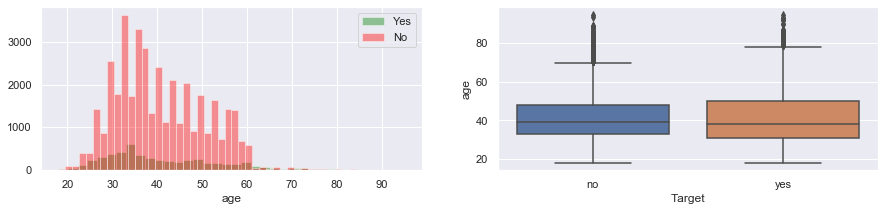

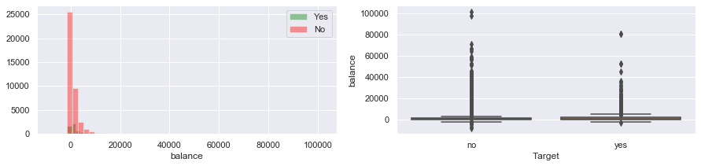

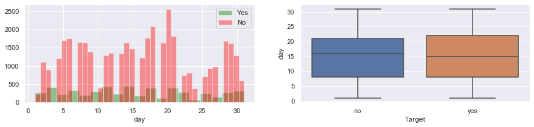

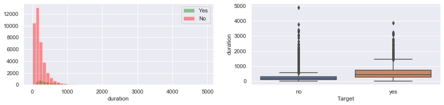

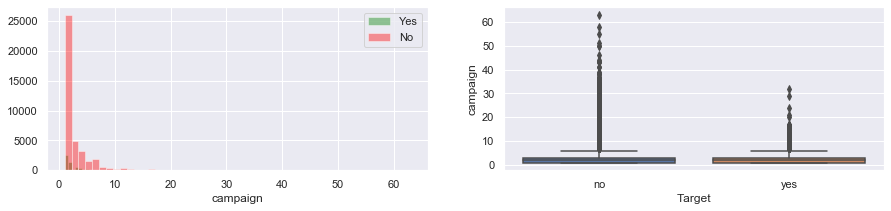

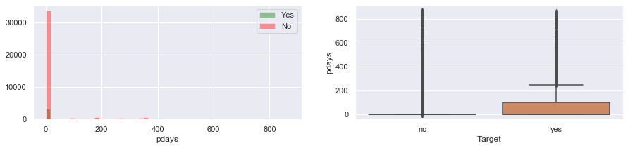

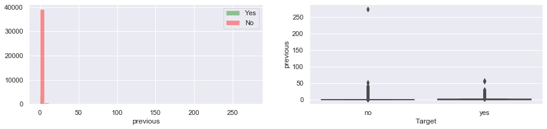

```python
sns.set(font_scale=1)
for c in df.columns[df.dtypes=='int64']:
    plt.figure(figsize=(15,3))
    plt.subplot(1,2,1)
    sns.distplot(df[df['Target']=='yes'][c], kde=False, color='green', label='Yes')
    sns.distplot(df[df['Target']=='no'][c], kde=False, color='red', label='No')
    plt.legend()

    plt.subplot(1,2,2)
    sns.boxplot(df.Target, df[c])

    plt.show()
```

**Comments**

- No strong correlation could be observed between any two parameters from pairplots.
- The countplot of categorical variables are generated with "Target" as a hue.
- Histogram and boxplots are generated for continuous variables with "Target" as a hue.
- This exercise illustrates the relation of "Target" variable with the other variables.
- Due to highly bias nature of the data, the histogram or count of Target="No" is obsuring any possible pattern.
- Additionally, high count of 'unknown' in 'contact' and 'poutcome' need to be handled carefully.

## Problem Statement : Deliverable – 2 (Prepare the data for analytics) – (10)

1. Ensure the attribute types are correct. If not, take appropriate actions.
2. Get the data model ready.
3. Transform the data i.e. scale / normalize if required
4. Create the training set and test set in ratio of 70:30

## Deliverable-2

- 'pdays' with -1 values were replaced with 900 as discussed earlier.
- 'unknown' are considered to be missing data. They will be dropped.
- After replaceing the 'unknown' values, dummy variables were created for all the categorical variables by one-hot-encoding.

```python
df.pdays = df.pdays.replace({-1:900})
df.replace({"unknown": None }, inplace=True)
df.dropna(inplace=True)
df.shape
```

```
(7842, 17)
```

### Comment:

- Data points got reduced from 45211 to only 7842. It is a drastic reductionof data point. In this version, we will work with this reduced dataset. As there are too many 'unknown' values, replacing them with some aggregate value might make the data biased. Hopefully dropping them and having a reduced set of data will keep the meanngfulness of the data intact.
- We will have a Version-2 with 'unknown' values replaced in a separate ipynb file.

```python
listoutvalues()
```

```
COLUMN:  job
management       1753
blue-collar      1537
technician       1289
admin.           1057
services          682
retired           458
self-employed     264
student           237
entrepreneur      211
unemployed        208
housemaid         146
Name: job, dtype: int64
------------------------------

COLUMN:  marital
married     4501
single      2454
divorced     887
Name: marital, dtype: int64
------------------------------

COLUMN:  education
secondary    4197
tertiary     2633
primary      1012
Name: education, dtype: int64
------------------------------

COLUMN:  default
no     7786
yes      56
Name: default, dtype: int64
------------------------------

COLUMN:  housing
yes    4942
no     2900
Name: housing, dtype: int64
------------------------------
```

[output cut: 26 more lines]

```
Name: month, dtype: int64
------------------------------

COLUMN:  poutcome
failure    4679
other      1750
success    1413
Name: poutcome, dtype: int64
------------------------------

COLUMN:  Target
no     6056
yes    1786
Name: Target, dtype: int64
------------------------------
```

- No more 'unknown' values.

```python
dummy_df=pd.get_dummies(df,drop_first=True)
```

```python
dummy_df
```

|  | age | balance | day | duration | campaign | pdays | previous | job_blue-collar | job_entrepreneur | job_housemaid | ... | month_jul | month_jun | month_mar | month_may | month_nov | month_oct | month_sep | poutcome_other | poutcome_success | Target_yes |
| --- | --- | --- | --- | --- | --- | --- | --- | --- | --- | --- | --- | --- | --- | --- | --- | --- | --- | --- | --- | --- | --- |
| 24060 | 33 | 882 | 21 | 39 | 1 | 151 | 3 | 0 | 0 | 0 | ... | 0 | 0 | 0 | 0 | 0 | 1 | 0 | 0 | 0 | 0 |
| 24062 | 42 | -247 | 21 | 519 | 1 | 166 | 1 | 0 | 0 | 0 | ... | 0 | 0 | 0 | 0 | 0 | 1 | 0 | 1 | 0 | 1 |
| 24064 | 33 | 3444 | 21 | 144 | 1 | 91 | 4 | 0 | 0 | 0 | ... | 0 | 0 | 0 | 0 | 0 | 1 | 0 | 0 | 0 | 1 |
| 24072 | 36 | 2415 | 22 | 73 | 1 | 86 | 4 | 0 | 0 | 0 | ... | 0 | 0 | 0 | 0 | 0 | 1 | 0 | 1 | 0 | 0 |
| 24077 | 36 | 0 | 23 | 140 | 1 | 143 | 3 | 0 | 0 | 0 | ... | 0 | 0 | 0 | 0 | 0 | 1 | 0 | 0 | 0 | 1 |
| ... | ... | ... | ... | ... | ... | ... | ... | ... | ... | ... | ... | ... | ... | ... | ... | ... | ... | ... | ... | ... | ... |
| 45199 | 34 | 1475 | 16 | 1166 | 3 | 530 | 12 | 1 | 0 | 0 | ... | 0 | 0 | 0 | 0 | 1 | 0 | 0 | 1 | 0 | 0 |
| 45201 | 53 | 583 | 17 | 226 | 1 | 184 | 4 | 0 | 0 | 0 | ... | 0 | 0 | 0 | 0 | 1 | 0 | 0 | 0 | 1 | 1 |
| 45204 | 73 | 2850 | 17 | 300 | 1 | 40 | 8 | 0 | 0 | 0 | ... | 0 | 0 | 0 | 0 | 1 | 0 | 0 | 0 | 0 | 1 |
| 45208 | 72 | 5715 | 17 | 1127 | 5 | 184 | 3 | 0 | 0 | 0 | ... | 0 | 0 | 0 | 0 | 1 | 0 | 0 | 0 | 1 | 1 |
| 45210 | 37 | 2971 | 17 | 361 | 2 | 188 | 11 | 0 | 1 | 0 | ... | 0 | 0 | 0 | 0 | 1 | 0 | 0 | 1 | 0 | 0 |

7842 rows × 39 columns

```python
from sklearn.model_selection import train_test_split
X = dummy_df.drop('Target_yes',axis=1)
y = dummy_df['Target_yes']

X_train, X_test, y_train, y_test = train_test_split(X, y, test_size=0.3, random_state=123)
```

## Problem Statement : Deliverable – 3 (create the ensemble model) – (30)

1. First create models using Logistic Regression and Decision Tree algorithm. Note the model performance by using different matrices. Use confusion matrix to evaluate class level metrics i.e. Precision/Recall. Also reflect the accuracy and F1 score of the model. (10 marks)
2. Build the ensemble models (Bagging and Boosting) and note the model performance by using different matrices. Use same metrics as in above model. (at least 3 algorithms) (15 marks)

## Deliverable - 3

```python
from sklearn.metrics import confusion_matrix, recall_score, precision_score, f1_score, roc_auc_score,accuracy_score
from sklearn.metrics import roc_curve

from IPython.display import Markdown, display
def printmd(string):
    display(Markdown(string))


def ModelEvaluation(mname, model, X_train, y_train, X_test, y_test):
    model.fit(X_train, y_train)
    y_predict =model.predict(X_test)

    #Confusion Matrix
    cm = confusion_matrix(y_test,y_predict,labels=[1,0])

    df_cm = pd.DataFrame(cm, index = ["True 1","True 0"],
                  columns = ["Predict 1","Predict 0"])

    #Scores
    score_in=model.score(X_train, y_train)
    score_out=model.score(X_test, y_test)

    recall= recall_score(y_test, y_predict)
    precision = precision_score(y_test, y_predict)
    accuracy = accuracy_score(y_test, y_predict)
    errorrate = 1 - accuracy
    f1score = f1_score(y_test, y_predict)
    roc_auc = roc_auc_score(y_test,y_predict)


    return_dict = {"model":mname, "in_sample_score": score_in, "out_of_sample_score": score_out, "recall": recall, \
                   "precision": precision, "accuracy": accuracy, "error rate": errorrate, "f1score": f1score, \
                   "roc_auc": roc_auc}

    printmd("## Evaluation Scores of {} ".format(mname))
    print("In Sample Score\t\t: {:.5f}".format(score_in))
    print("Out Of Sample Score\t: {:.5f}".format(score_out))

    print("Recall Score \t\t: {:.5f}".format(recall))
    print("Precision Score \t: {:.5f}".format(precision))

    print("F1 Score\t\t: {:.5f}".format(f1score))
    print("Accuracy\t\t: {:.5f}".format(accuracy))
    print("Error Rate\t\t: {:.5f}".format(errorrate))
    print("Roc Auc Score\t\t: {:.5f}".format(roc_auc))

    #ROC Data
    fpr, tpr, thresholds = roc_curve(y_test, model.predict_proba(X_test)[:,1])

    #Plotting
    plt.figure(figsize = (18,7))
    plt.suptitle(mname)
    plt.subplot(1,2,1)
    sns.set(font_scale=1.8)
    sns.heatmap(df_cm,annot=True,fmt='0000',cmap='plasma');
    plt.title('Confusion Matrix')

    plt.subplot(1,2,2)
    plt.plot(fpr, tpr, label='Area = %0.2f' % roc_auc)
    plt.plot([0, 1], [0, 1],'r--')
    plt.xlim([-0.05, 1.05])
    plt.ylim([-0.05, 1.05])
    #plt.xlabel("False Positive Rate")
    #plt.ylabel("True Positive Rate")
    plt.title("Receiver Operating Characteristic")
    plt.legend(loc="lower right")
    plt.savefig('Log_ROC')
    plt.show()
    return(return_dict)
```

Evaluation Scores of Logistic Regression

```
In Sample Score		: 0.84351
Out Of Sample Score	: 0.83893
Recall Score 		: 0.54086
Precision Score 	: 0.66033
F1 Score		: 0.59465
Accuracy		: 0.83893
Error Rate		: 0.16107
Roc Auc Score		: 0.73155
```

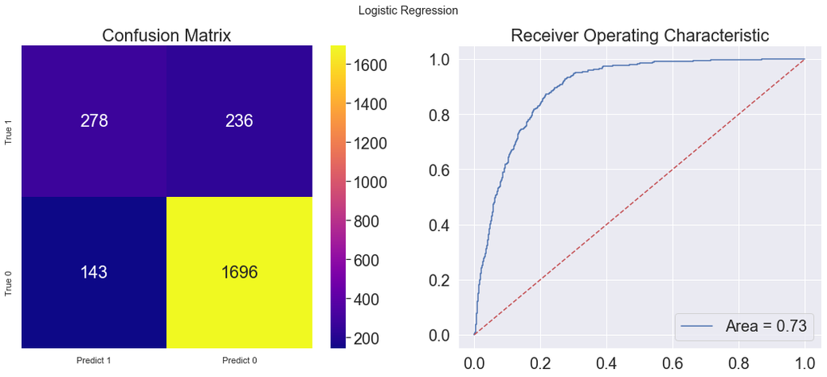

```python
df_result = pd.DataFrame(columns=['model', 'in_sample_score', 'out_of_sample_score', 'recall', 'precision', 'accuracy' \
                                         , 'error rate', 'f1score', 'roc_auc'])


from sklearn.linear_model import LogisticRegression
m_logr = LogisticRegression(solver="liblinear")
result = ModelEvaluation("Logistic Regression", m_logr,X_train, y_train, X_test, y_test)
df_result = df_result.append(result, ignore_index=True)
```

Evaluation Scores of Decision Tree Classifier

```
In Sample Score		: 1.00000
Out Of Sample Score	: 0.79941
Recall Score 		: 0.57782
Precision Score 	: 0.53804
F1 Score		: 0.55722
Accuracy		: 0.79941
Error Rate		: 0.20059
Roc Auc Score		: 0.71958
```

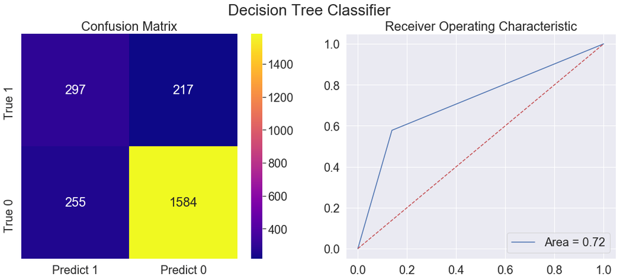

```python
from sklearn.tree import DecisionTreeClassifier
m_dTree = DecisionTreeClassifier(criterion = 'entropy', random_state=123)
result = ModelEvaluation("Decision Tree Classifier",m_dTree,X_train, y_train, X_test, y_test)
df_result = df_result.append(result, ignore_index=True)
```

## Reduced Decision Tree

Evaluation Scores of Decision Tree Classifier (Reduced)

```
In Sample Score		: 0.83895
Out Of Sample Score	: 0.84105
Recall Score 		: 0.58171
Precision Score 	: 0.65284
F1 Score		: 0.61523
Accuracy		: 0.84105
Error Rate		: 0.15895
Roc Auc Score		: 0.74763
```

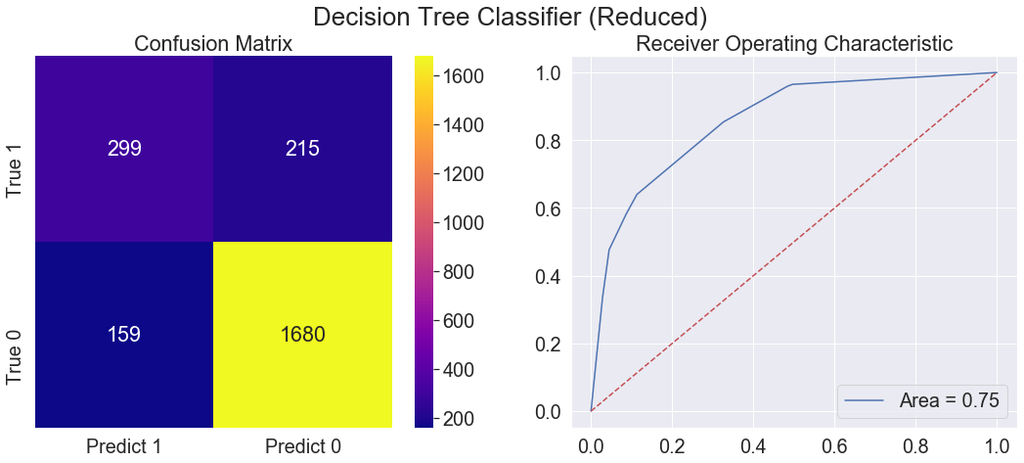

```python
m_dTreeR = DecisionTreeClassifier(criterion = 'entropy', max_depth=3, random_state=123)
result = ModelEvaluation("Decision Tree Classifier (Reduced)",m_dTreeR,X_train, y_train, X_test, y_test)
df_result = df_result.append(result, ignore_index=True)
```

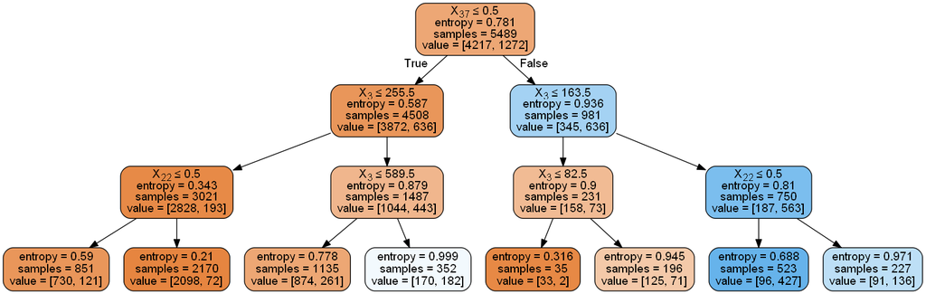

```python
from sklearn.tree import export_graphviz
from sklearn.externals.six import StringIO
from IPython.display import Image
import pydotplus
import graphviz

dot_data = StringIO()
export_graphviz(m_dTreeR, out_file=dot_data,
                filled=True, rounded=True,
                special_characters=True)
graph = pydotplus.graph_from_dot_data(dot_data.getvalue())
graph.write_png('dTreeR.png')
Image(graph.create_png())
```

Evaluation Scores of Bagging Classifier

```
In Sample Score		: 0.99945
Out Of Sample Score	: 0.85253
Recall Score 		: 0.59922
Precision Score 	: 0.68597
F1 Score		: 0.63967
Accuracy		: 0.85253
Error Rate		: 0.14747
Roc Auc Score		: 0.76127
```

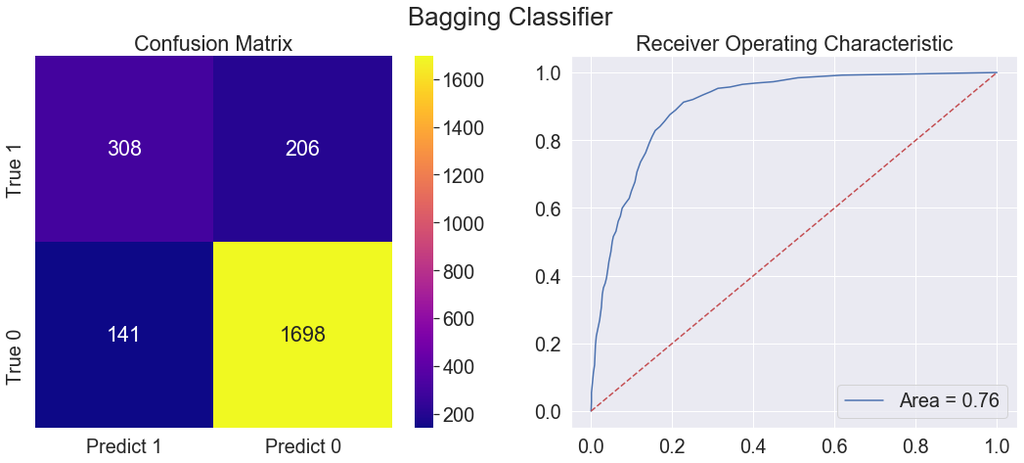

```python
from sklearn.ensemble import BaggingClassifier
m_bagc = BaggingClassifier(base_estimator=m_dTree, n_estimators=50,random_state=1)
result = ModelEvaluation("Bagging Classifier",m_bagc,X_train, y_train, X_test, y_test)
df_result = df_result.append(result, ignore_index=True)
```

Evaluation Scores of AdaBoost Classifier

```
In Sample Score		: 0.85189
Out Of Sample Score	: 0.84870
Recall Score 		: 0.58171
Precision Score 	: 0.67955
F1 Score		: 0.62683
Accuracy		: 0.84870
Error Rate		: 0.15130
Roc Auc Score		: 0.75252
```

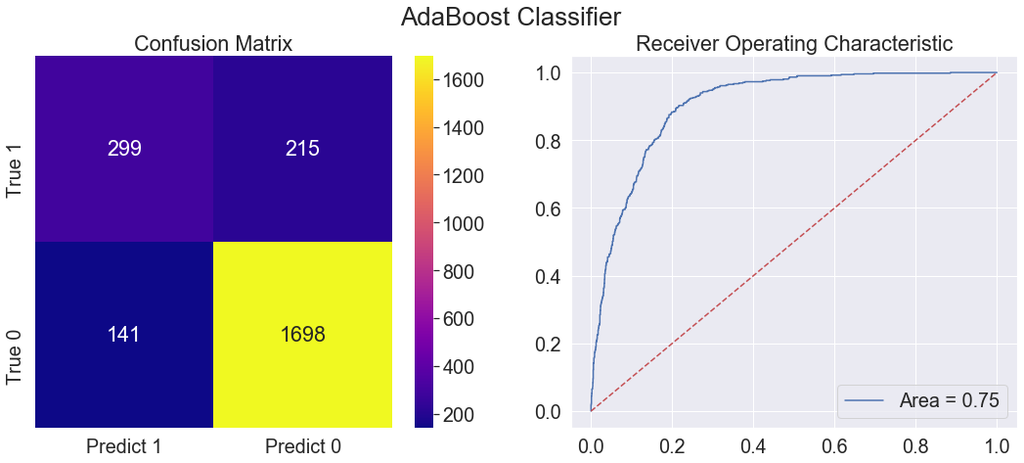

```python
from sklearn.ensemble import AdaBoostClassifier
m_adab = AdaBoostClassifier(n_estimators=50, random_state=1)
result = ModelEvaluation("AdaBoost Classifier",m_adab,X_train, y_train, X_test, y_test)
df_result = df_result.append(result, ignore_index=True)
```

Evaluation Scores of Gradient Boosting Classifier

```
In Sample Score		: 0.86846
Out Of Sample Score	: 0.85465
Recall Score 		: 0.56031
Precision Score 	: 0.71287
F1 Score		: 0.62745
Accuracy		: 0.85465
Error Rate		: 0.14535
Roc Auc Score		: 0.74862
```

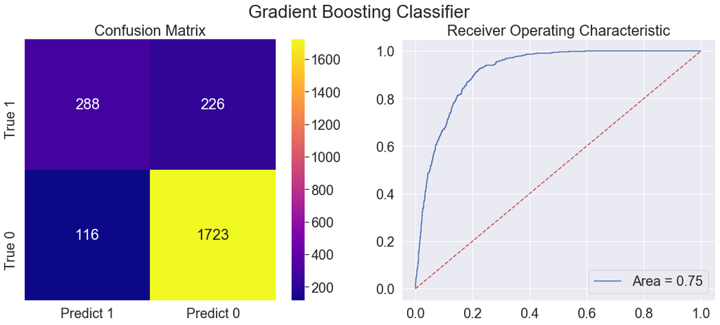

```python
from sklearn.ensemble import GradientBoostingClassifier
m_grdb = GradientBoostingClassifier(n_estimators = 50,random_state=1)
result = ModelEvaluation("Gradient Boosting Classifier",m_grdb,X_train, y_train, X_test, y_test)
df_result = df_result.append(result, ignore_index=True)
```

Evaluation Scores of Random Forest Classifier

```
In Sample Score		: 0.99964
Out Of Sample Score	: 0.85635
Recall Score 		: 0.56420
Precision Score 	: 0.71782
F1 Score		: 0.63181
Accuracy		: 0.85635
Error Rate		: 0.14365
Roc Auc Score		: 0.75111
```

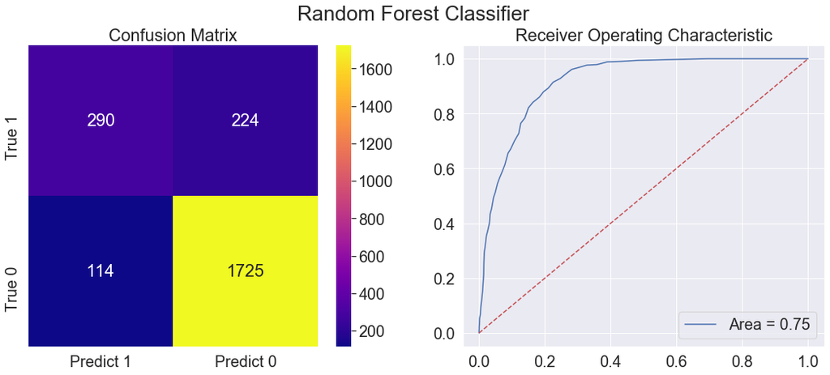

```python
from sklearn.ensemble import RandomForestClassifier
m_rf = RandomForestClassifier(n_estimators = 50, random_state=123, max_features=8)
result = ModelEvaluation("Random Forest Classifier",m_rf,X_train, y_train, X_test, y_test)
df_result = df_result.append(result, ignore_index=True)
```

## Summary Result

```python
df_result
```

|  | model | in_sample_score | out_of_sample_score | recall | precision | accuracy | error rate | f1score | roc_auc |
| --- | --- | --- | --- | --- | --- | --- | --- | --- | --- |
| 0 | Logistic Regression | 0.8435 | 0.8389 | 0.5409 | 0.6603 | 0.8389 | 0.1611 | 0.5947 | 0.7315 |
| 1 | Decision Tree Classifier | 1.0000 | 0.7994 | 0.5778 | 0.5380 | 0.7994 | 0.2006 | 0.5572 | 0.7196 |
| 2 | Decision Tree Classifier (Reduced) | 0.8390 | 0.8411 | 0.5817 | 0.6528 | 0.8411 | 0.1589 | 0.6152 | 0.7476 |
| 3 | Bagging Classifier | 0.9995 | 0.8525 | 0.5992 | 0.6860 | 0.8525 | 0.1475 | 0.6397 | 0.7613 |
| 4 | AdaBoost Classifier | 0.8519 | 0.8487 | 0.5817 | 0.6795 | 0.8487 | 0.1513 | 0.6268 | 0.7525 |
| 5 | Gradient Boosting Classifier | 0.8685 | 0.8547 | 0.5603 | 0.7129 | 0.8547 | 0.1453 | 0.6275 | 0.7486 |
| 6 | Random Forest Classifier | 0.9996 | 0.8564 | 0.5642 | 0.7178 | 0.8564 | 0.1436 | 0.6318 | 0.7511 |

- Various models were used to predict potential customers who would opt for Term Deposit from the bank.
- Various scores of the models listed out.
- A maximum ROC_AUC score of 0.7613 could be achieved with Bagging Classifier. This model also has the maximum recall rate of 0.5992.